# **Introduction to Git and GitHub**

## **Tagging users and creating issues in GitHub**

As we already saw, other users can work on a specific project and make modifications to the repository. But to have a better control of this we can add or restrict the access to specific users, create issues so users can create or fix a specific piece of code, or tag them to notify about certain issues they need to check.

[figure not shown]

It is also possible to create a new issue, so we can have better control over what each user is doing. To do that, go to the issues tab and simply click on “New issue”. In this area, it is possible to add a title for the issue, write a message, but also to assign specific users to the user so they can be notified of specific task they need to work on.

[figure not shown]

Once the issue is resolved (and the user committed and pushed the changes to the remote repository), the user can simply click go to the issue and click on close issue, so it is no longer listed as open. But remember, because Git keeps track of all the changes, the issue can be re-open if necessary.

## **Final Recap**

The image below provides a general recap of how the Git process workload. The first step is to move (add) the files from the local working area to the staging phase, so we can commit and push the files from the local repository to the remote repository, and in the opposite way, we need to pull the files from the remote repository to the local repository to keep all the local files up to date. Checkout allows switching between repository versions or branches.

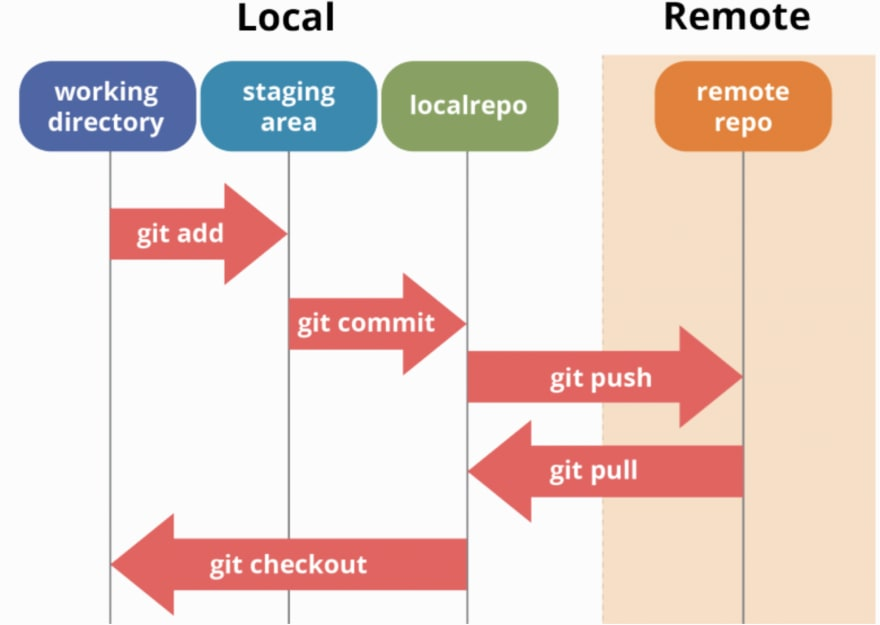

Image source: https://github.com/szalam/gitwintut